# Kyrgyzstan MICS 2023

# What a reader might need to know about the modeling process

## Pipeline

The development of models and variable selection was following the logic below:

1. First, we run a null model to check whether multilevel approach is justified at all
2. Next, we run a model with the most exhaustive list of predictors that are shared accross countries’ datasets, called a “model for pooling”. This model is run through anova to see whether it fits the data significantly better than the null model.
3. After that, we do a little robustness check, running (almost) the same model for pooling through the regular logistic regression rather than multilevel one.
4. Then, we include all variables available for the country (that are of our interest) into a “full” model and check whether it is significantly different in prediction than a model for pooling.
5. Also, we are tracking r^2 and collinearity metrics all way along.
6. As a next step, we remove all non-significant variables from a full model, calling this model “model_sign”, and based on it, conduct some questionable experiments with interactions and random slopes and call it ‘model_extra’
7. Finally, we are actually doing some machine learning-style performance evaluation of all of the models, preserving the formulas, but re-training them on randomly (but within stratas) split data.

# Loading data

```r
# Indiv-level data
kyrgyzstan_mics <- get_and_preprocess_mics_data("Kyrgyzstan")

# Region-level data
region_kg <- read_csv("../data/raw/regional_data_Kyrgyzstan_2023.csv")
```

# Preprocessing individual level data

## Dimensionality reduction

```r
kyrgyzstan_mics <- kyrgyzstan_mics %>%

  # Learning materials
  recode_playthings(books_var = "EC1",
                    playthings_vars = c("EC2A", "EC2B", "EC2C")) %>%

  # Inadequate supervision
  recode_supervision(supervision_vars = c("EC3A", "EC3B")) %>%

  # Child discipline - psychological aggression
  recode_psy_aggression(var1 = "UCD2D", var2 = "UCD2H") %>%

  # Early stimulation and responsive care
  recode_early_stimulation_v2(
    activity_prefixes = c("EC5A", "EC5B", "EC5C", "EC5D", "EC5E", "EC5F")) %>%

  # ECDI
  recode_ecdi_and_track(age_col = "CAGE",
                        ec_regular = paste0("EC", 21:38),
                        ec_frequency = "EC39",
                        ec_comparison = "EC40") %>%
  mutate(UB8=if_else(UB8==1, 1,0)) %>%
  mutate(HC10E=if_else(HC10E==1, 1,0)) %>%


  # Social transfers
  recode_economic_assistance(unit_base = "ST4U$",
                                          number_base = "ST4N$",
                                          n_programs = 5,
                                          months_threshold = 3) %>%
  # Caregiver's education
  recode_education_scheme("ED5A", "KG") %>%

  # Exclude children under 3
  filter(CAGE>35) %>%

  # Sample one child from household
  sample_one_per_group(group_var = "house_index",
                       seed = 42) %>%

  # Omit rows with missing values for key predictors
  filter_at(vars(ED5A, HL13, HL17), all_vars(!is.na(.)))
```

## Imputation

```r
kyrgyzstan_mics$UB8[is.na(kyrgyzstan_mics$UB8)] <- 0
```

# Correlations and associations

```r
results <- pairwise_chi_cramers_parallel(
  kyrgyzstan_mics[, names(kyrgyzstan_mics) %in% c("UB2", "ED5A","UB8","HH48", "HH51","HC10E", "HH7", "HH6", "HL13", "HL17", "windex5", "ED4", "playthings_sum", "two_plus_playthings", "supervised_inadequately", "psy_aggression", "early_stimulation", "ecdi_sum", "dev_on_track", "received_econ_assist" )], n_cores = 4, p_threshold = 0.05, use_bonferroni = FALSE)
```

```
## Processing 190 pairs using 4 cores...
## Found 86 significant pairs
```

```r
# Get summary
summary_stats(results)
```

```
##
## === Association Analysis Summary ===
##
## Total variables: 20
## Possible pairs: 190
## Computed pairs: 190
## Significant pairs: 86 (45.3%)
## Adjusted p-value threshold: 5.00e-02
##
## --- Cramer's V Statistics (Significant Associations) ---
## Mean: 0.202
## Median: 0.144
## Min: 0.056
## Max: 1.000
##
## --- Effect Size Distribution ---
## Weak (< 0.1): 48 (27.9%)
## Small (0.1-0.3): 100 (58.1%)
## Medium (0.3-0.5): 14 (8.1%)
## Large (>= 0.5): 10 (5.8%)
```

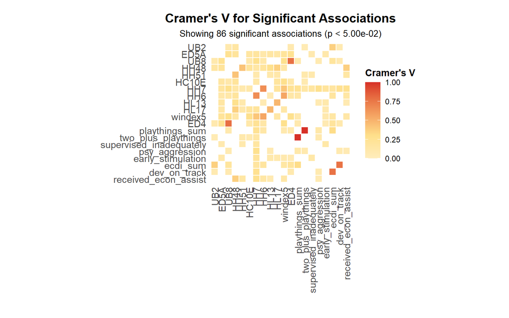

```r
# Create heatmap
plot <- plot_cramers_heatmap(results, text_size_x = 11, text_size_y = 11)
print(plot)
```

```r
# View top associations
top_20 <- get_top_associations(results, n = 20)
print(top_20)
```

```
##               Var1                 Var2  CramersV  ChiSquare        PValue
## 91  playthings_sum  two_plus_playthings 1.0000000 1264.00000 9.528932e-274
## 58             UB8                  ED4 0.7856210  780.14126 1.121441e-171
## 171       ecdi_sum         dev_on_track 0.7701384  749.69498 6.626078e-146
## 28             HH7                  HH6 0.6596972  550.09333 1.240409e-113
## 53             HH6              windex5 0.5541418  388.14043  1.015237e-82
## 45            HL13                 HL17 0.4827191  294.53438  5.111890e-66
## 10            HH48                 HH51 0.4290187 1163.24051 9.103802e-198
## 52             HH7              windex5 0.4161563  875.62893 2.385334e-163
## 175           HH48 received_econ_assist 0.3733373  176.17725  3.855159e-30
## 137            UB2             ecdi_sum 0.3705060  173.51524  1.793028e-26
## 40            HH48                 HL17 0.3685480  171.68614  3.124619e-29
## 149 playthings_sum             ecdi_sum 0.3148509  375.90499  2.795215e-47
## 51           HC10E              windex5 0.2901122  106.38467  4.293388e-22
## 18             UB8                  HH7 0.2841873  102.08371  1.600291e-18
## 48             UB8              windex5 0.2821684  100.63842  7.193257e-21
## 66         windex5                  ED4 0.2820133  100.52784  7.593978e-21
## 32            HH48                 HL13 0.2817472  100.33823  4.084743e-15
## 112            HH7       psy_aggression 0.2782882   97.88963  1.151822e-17
## 178            HH7 received_econ_assist 0.2686180   91.20473  2.647430e-16
## 160            HH7         dev_on_track 0.2653583   89.00462  7.404216e-16
```

# Combining data for multilevel modeling

```r
# If we decide to grand-center anything
region_kg <- region_kg %>%
  # Log-transform to compress the scale
  mutate(popul_mln_total_01012023 = popul_thsnd_total_01012023/1000)
region_kg <- grand_mean_centering(region_kg, colnames(region_kg)[-c(1:2)])
region_kg <- region_kg %>%
  # Log-transform to compress the scale
  mutate(popul_density_log = log(popul_density),
         total_pre_2023_log = log(total_pre_2023),
         expen_on_pre_2023_log = log(expen_on_pre_2023))

kgz_df <- kyrgyzstan_mics %>%
  mutate(region_mics = as.character(as_factor(HH7))) %>%
  left_join(region_kg,
            by = "region_mics",
            keep = FALSE)
```

# Modeling

## Baseline models

### Null model

```r
# RANDOM INTERCEPT WITH FIXED SLOPES

# Null model (unconditional model) - to calculate ICC
model_null <- glmer(
  UB8 ~ 1 + (1 | region_mics),
  data = kgz_df,
  family = binomial(link = "logit"),
  control = glmerControl(optimizer = "bobyqa", optCtrl = list(maxfun = 100000))
)

# Calculate Intraclass Correlation Coefficient (ICC)
# ICC tells us how much variance is due to clustering
# An ICC > 0.05 or 0.10 or typically justifies using a multilevel model
vpc_null <- performance::icc(model_null)
print(paste("ICC:", round(vpc_null$ICC_adjusted, 3)))
```

```
## [1] "ICC: 0.114"
```

### All individual predictors + universal regional predictors

```r
# Baseline random intercept model
model_for_pooling <- glmer(
  UB8 ~
    # Level 1 predictors (child/household)
    CAGE + # Age in months
    ED5A + # mother's/caregiver's education
    EC1 + #Three or more books
    two_plus_playthings +
    supervised_inadequately +
    psy_aggression +
    early_stimulation +
    dev_on_track +
    HH6 + # Rural/urban
    HH48 + # household size
    HL13 + # Natural mother lives in the household
    HL17 + # Natural father lives in the household
    windex5 +
    HC10E + # Family has a car

    # Level 2 predictors (structure)
    popul_mln_total_01012023 +
    popul_density_log +
    total_pre_2023_log +

    # Random intercept for region
    (1 | region),

  data = kgz_df,
  family = binomial(link = "logit"),
  control = glmerControl(optimizer = "bobyqa", optCtrl = list(maxfun = 100000))
)

# Model summary
summary(model_for_pooling, correlation =TRUE)
```

```
## Generalized linear mixed model fit by maximum likelihood (Laplace
##   Approximation) [glmerMod]
##  Family: binomial  ( logit )
## Formula:
## UB8 ~ CAGE + ED5A + EC1 + two_plus_playthings + supervised_inadequately +
##     psy_aggression + early_stimulation + dev_on_track + HH6 +
##     HH48 + HL13 + HL17 + windex5 + HC10E + popul_mln_total_01012023 +
##     popul_density_log + total_pre_2023_log + (1 | region)
##    Data: kgz_df
## Control: glmerControl(optimizer = "bobyqa", optCtrl = list(maxfun = 1e+05))
##
##       AIC       BIC    logLik -2*log(L)  df.resid
##    1479.8    1577.5    -720.9    1441.8      1245
##
## Scaled residuals:
##     Min      1Q  Median      3Q     Max
## -2.4202 -0.7104 -0.4089  0.8355  4.0431
##
## Random effects:
##  Groups Name        Variance Std.Dev.
##  region (Intercept) 0.03018  0.1737
## Number of obs: 1264, groups:  region, 9
##
## Fixed effects:
##                            Estimate Std. Error z value Pr(>|z|)
## (Intercept)              -11.250313   2.488647  -4.521 6.16e-06 ***
## CAGE                       0.029987   0.009742   3.078  0.00208 **
## ED5A                       0.403463   0.079314   5.087 3.64e-07 ***
## EC1                        0.634398   0.154190   4.114 3.88e-05 ***
## two_plus_playthings        0.212040   0.224355   0.945  0.34460
## supervised_inadequately   -0.036145   0.235279  -0.154  0.87790
## psy_aggression             0.130873   0.137790   0.950  0.34221
## early_stimulation          0.223444   0.205213   1.089  0.27622
## dev_on_track               0.313921   0.146775   2.139  0.03245 *
## HH6                       -0.101983   0.190882  -0.534  0.59315
## HH48                      -0.031993   0.038620  -0.828  0.40744
## HL13                       0.927244   0.305748   3.033  0.00242 **
## HL17                      -0.242114   0.223385  -1.084  0.27844
## windex5                    0.293926   0.066406   4.426 9.59e-06 ***
## HC10E                      0.133590   0.144644   0.924  0.35571
```

[output cut: 33 more lines]

```
## dev_on_trck
## HH6
## HH48         0.022
## HL13        -0.034  0.073
## HL17         0.034  0.166 -0.499
## windex5      0.296  0.104  0.034 -0.043
## HC10E       -0.080 -0.180 -0.091  0.169 -0.277
## p___0101202 -0.127  0.069 -0.040  0.107 -0.171  0.046
## ppl_dnsty_l  0.422 -0.036  0.041 -0.077  0.025 -0.019 -0.678
## ttl_p_2023_  0.114 -0.082  0.027 -0.112  0.242 -0.062 -0.947  0.650
## optimizer (bobyqa) convergence code: 0 (OK)
## Model failed to converge with max|grad| = 0.0109921 (tol = 0.002, component 1)
##   See ?lme4::convergence and ?lme4::troubleshooting.
## Model is nearly unidentifiable: large eigenvalue ratio
##  - Rescale variables?
```

```r
or_model <- model_for_pooling
ame_model <- avg_slopes(model_for_pooling, type = "response")

modelsummary(
  list(
    "Odds Ratios" = or_model,
    "Marginal Effects" = ame_model
  ),
  exponentiate = c(TRUE, FALSE),
  statistic = "conf.int",
  stars = TRUE,
  output = "gt"
)
```

|  | Odds Ratios | Marginal Effects |
| --- | --- | --- |
| (Intercept) | 0.000*** |  |
|  | [0.000, 0.002] |  |
| CAGE | 1.030** | 0.006** |
|  | [1.011, 1.050] | [0.002, 0.009] |
| ED5A | 1.497*** | 0.078*** |
|  | [1.281, 1.749] | [0.049, 0.107] |
| EC1 | 1.886*** | 0.128*** |
|  | [1.394, 2.551] | [0.066, 0.190] |
| two_plus_playthings | 1.236 | 0.040 |
|  | [0.796, 1.919] | [-0.042, 0.123] |
| supervised_inadequately | 0.965 | -0.007 |
|  | [0.608, 1.530] | [-0.096, 0.082] |
| psy_aggression | 1.140 | 0.025 |
|  | [0.870, 1.493] | [-0.027, 0.078] |
| early_stimulation | 1.250 | 0.043 |
|  | [0.836, 1.869] | [-0.033, 0.118] |
| dev_on_track | 1.369* | 0.060* |
|  | [1.027, 1.825] | [0.006, 0.115] |
| HH6 | 0.903 | -0.020 |
|  | [0.621, 1.313] | [-0.092, 0.053] |
| HH48 | 0.969 | -0.006 |
|  | [0.898, 1.045] | [-0.021, 0.008] |
| HL13 | 2.528** | 0.180** |
|  | [1.388, 4.602] | [0.065, 0.294] |
| HL17 | 0.785 | -0.047 |
|  | [0.507, 1.216] | [-0.131, 0.038] |
| windex5 | 1.342*** | 0.057*** |
|  | [1.178, 1.528] | [0.032, 0.081] |
| HC10E | 1.143 | 0.026 |
|  | [0.861, 1.518] | [-0.029, 0.081] |
| popul_mln_total_01012023 | 0.056*** | -0.558*** |
|  | [0.015, 0.209] | [-0.802, -0.313] |
| popul_density_log | 1.101 | 0.019 |
|  | [0.964, 1.259] | [-0.007, 0.044] |
| total_pre_2023_log | 4.789** | 0.303** |
|  | [1.809, 12.682] | [0.118, 0.489] |
| SD (Intercept region) | 0.174 |  |
| Num.Obs. | 1264 | 1264 |
| R2 Marg. | 0.235 | 0.235 |
| R2 Cond. | 0.242 | 0.242 |
| AIC | 1479.8 | 1479.8 |
| BIC | 1577.5 | 1577.5 |
| ICC | 0.0 | 0.0 |
| RMSE | 0.44 | 0.44 |

+ p < 0.1, * p < 0.05, ** p < 0.01, *** p < 0.001

```r
anova(model_null, model_for_pooling)
```

```
## Data: kgz_df
## Models:
## model_null: UB8 ~ 1 + (1 | region_mics)
## model_for_pooling: UB8 ~ CAGE + ED5A + EC1 + two_plus_playthings + supervised_inadequately + psy_aggression + early_stimulation + dev_on_track + HH6 + HH48 + HL13 + HL17 + windex5 + HC10E + popul_mln_total_01012023 + popul_density_log + total_pre_2023_log + (1 | region)
##                   npar    AIC    BIC  logLik -2*log(L)  Chisq Df Pr(>Chisq)
## model_null           2 1598.8 1609.1 -797.43    1594.8
## model_for_pooling   19 1479.8 1577.5 -720.88    1441.8 153.09 17  < 2.2e-16 ***
## ---
## Signif. codes:  0 '***' 0.001 '**' 0.01 '*' 0.05 '.' 0.1 ' ' 1
```

```r
check_collinearity(model_for_pooling)
```

```
## # Check for Multicollinearity
##
## Low Correlation
##
##                     Term  VIF     VIF 95% CI adj. VIF Tolerance
##                     CAGE 1.02 [ 1.00,  1.32]     1.01      0.98
##                     ED5A 1.13 [ 1.08,  1.22]     1.06      0.88
##                      EC1 1.15 [ 1.09,  1.24]     1.07      0.87
##      two_plus_playthings 1.04 [ 1.01,  1.18]     1.02      0.96
##  supervised_inadequately 1.03 [ 1.00,  1.24]     1.01      0.98
##           psy_aggression 1.07 [ 1.03,  1.17]     1.03      0.94
##        early_stimulation 1.06 [ 1.02,  1.17]     1.03      0.94
##             dev_on_track 1.02 [ 1.00,  1.32]     1.01      0.98
##                      HH6 1.59 [ 1.48,  1.72]     1.26      0.63
##                     HH48 1.16 [ 1.10,  1.25]     1.07      0.87
##                     HL13 1.44 [ 1.35,  1.56]     1.20      0.69
##                     HL17 1.52 [ 1.42,  1.64]     1.23      0.66
##                  windex5 1.61 [ 1.50,  1.75]     1.27      0.62
##                    HC10E 1.19 [ 1.13,  1.28]     1.09      0.84
##        popul_density_log 2.76 [ 2.53,  3.02]     1.66      0.36
##  Tolerance 95% CI
##      [0.76, 1.00]
##      [0.82, 0.93]
##      [0.81, 0.91]
##      [0.85, 0.99]
##      [0.80, 1.00]
##      [0.86, 0.97]
##      [0.86, 0.98]
##      [0.76, 1.00]
##      [0.58, 0.68]
##      [0.80, 0.91]
##      [0.64, 0.74]
##      [0.61, 0.70]
##      [0.57, 0.66]
##      [0.78, 0.89]
##      [0.33, 0.40]
##
## High Correlation
##
##                      Term   VIF     VIF 95% CI adj. VIF Tolerance
##  popul_mln_total_01012023 11.37 [10.25, 12.62]     3.37      0.09
##        total_pre_2023_log 11.09 [10.00, 12.30]     3.33      0.09
##  Tolerance 95% CI
##      [0.08, 0.10]
##      [0.08, 0.10]
```

```r
r2(model_for_pooling)
```

```
## # R2 for Mixed Models
##
##   Conditional R2: 0.242
##      Marginal R2: 0.235
```

```r
r2(model_null)
```

```
## # R2 for Mixed Models
##
##   Conditional R2: 0.114
##      Marginal R2: 0.000
```

```r
# Robustness check
model_fe_region <- glm(
  UB8 ~ CAGE + # Age in months
    ED5A + # mother's/caregiver's education
    EC1 + #Three or more books
    two_plus_playthings +
    supervised_inadequately +
    psy_aggression +
    early_stimulation +
    dev_on_track +
    HH6 + # Rural/urban
    HH48 + # household size
    HL13 + # Natural mother lives in the household
    HL17 + # Natural father lives in the household
    windex5 +
    HC10E + # Family has a car

    # Level 2 predictors (structure)
    popul_mln_total_01012023 +
    popul_density_log +
    total_pre_2023_log +
    factor(region),
  data = kgz_df,
  family = binomial
)

modelsummary(
  list(
    "Multilevel model" = model_for_pooling,
    "Region Fixed Effects Model" = model_fe_region
  ),
  exponentiate = TRUE
)
```

```
## Model matrix is rank deficient. Parameters `factor(region)Osh City,
##   factor(region)Osh Region, factor(region)Talas Region` were not
##   estimable.
```

|  | Multilevel model | Region Fixed Effects Model |
| --- | --- | --- |
| (Intercept) | 0.000 | 0.001 |
|  | (0.000) | (0.003) |
| CAGE | 1.030 | 1.030 |
|  | (0.010) | (0.010) |
| ED5A | 1.497 | 1.519 |
|  | (0.119) | (0.121) |
| EC1 | 1.886 | 1.880 |
|  | (0.291) | (0.298) |
| two_plus_playthings | 1.236 | 1.267 |
|  | (0.277) | (0.286) |
| supervised_inadequately | 0.965 | 0.942 |
|  | (0.227) | (0.223) |
| psy_aggression | 1.140 | 1.111 |
|  | (0.157) | (0.154) |
| early_stimulation | 1.250 | 1.227 |
|  | (0.257) | (0.255) |
| dev_on_track | 1.369 | 1.316 |
|  | (0.201) | (0.197) |
| HH6 | 0.903 | 0.862 |
|  | (0.172) | (0.167) |
| HH48 | 0.969 | 0.964 |
|  | (0.037) | (0.037) |
| HL13 | 2.528 | 2.469 |
|  | (0.773) | (0.761) |
| HL17 | 0.785 | 0.809 |
|  | (0.175) | (0.183) |
| windex5 | 1.342 | 1.320 |
|  | (0.089) | (0.092) |
| HC10E | 1.143 | 1.163 |
|  | (0.165) | (0.170) |
| popul_mln_total_01012023 | 0.056 | 0.305 |
|  | (0.038) | (0.238) |
| popul_density_log | 1.101 | 0.991 |
|  | (0.075) | (0.070) |
| total_pre_2023_log | 4.789 | 1.821 |
|  | (2.380) | (0.952) |
| factor(region)Bishkek City |  | 0.719 |
|  |  | (0.297) |
| factor(region)Chui Region |  | 0.565 |
|  |  | (0.151) |
| factor(region)Issyk-Kul Region |  | 0.605 |
|  |  | (0.188) |
| factor(region)Jalal-Abad Region |  | 0.281 |
|  |  | (0.096) |
| factor(region)Naryn Region |  | 1.151 |
|  |  | (0.363) |
| SD (Intercept region) | 0.174 |  |
| Num.Obs. | 1264 | 1264 |
| R2 Marg. | 0.235 |  |
| R2 Cond. | 0.242 |  |
| AIC | 1479.8 | 1472.5 |
| BIC | 1577.5 | 1590.8 |
| ICC | 0.0 |  |
| Log.Lik. |  | -713.265 |
| RMSE | 0.44 | 0.44 |

### All available country-specific variables, fixed slopes

```r
model_full <- glmer(
    UB8 ~
    # Level 1 predictors (child/household)
    CAGE + # Age in months
    ED5A + # mother's/caregiver's education
    EC1 + #Three or more books
    two_plus_playthings +
    supervised_inadequately +
    psy_aggression +
    early_stimulation +
    dev_on_track +
    received_econ_assist + # Social transfers!
    HH6 + # Rural/urban
    HH48 + # household size
    HL13 + # Natural mother lives in the household
    HL17 + # Natural father lives in the household
    windex5 +
    HC10E + # Family has a car

    # Level 2 predictors (structure)
    popul_mln_total_01012023 +
    popul_density_log +
    total_pre_2023_log +
    expen_on_pre_2023_log +
    employment_rate_female_2023_c +
    employment_rate_male_2023_c +


    # Random intercept for region
    (1 | region),

  data = kgz_df,
  family = binomial(link = "logit"),
  control = glmerControl(optimizer = "bobyqa", optCtrl = list(maxfun = 100000))
)
```

```
## boundary (singular) fit: see help('isSingular')
```

```r
summary(model_full, correlation = TRUE)
```

```
## Generalized linear mixed model fit by maximum likelihood (Laplace
##   Approximation) [glmerMod]
##  Family: binomial  ( logit )
## Formula:
## UB8 ~ CAGE + ED5A + EC1 + two_plus_playthings + supervised_inadequately +
##     psy_aggression + early_stimulation + dev_on_track + received_econ_assist +
##     HH6 + HH48 + HL13 + HL17 + windex5 + HC10E + popul_mln_total_01012023 +
##     popul_density_log + total_pre_2023_log + expen_on_pre_2023_log +
##     employment_rate_female_2023_c + employment_rate_male_2023_c +
##     (1 | region)
##    Data: kgz_df
## Control: glmerControl(optimizer = "bobyqa", optCtrl = list(maxfun = 1e+05))
##
##       AIC       BIC    logLik -2*log(L)  df.resid
##    1472.9    1591.2    -713.5    1426.9      1241
##
## Scaled residuals:
##     Min      1Q  Median      3Q     Max
## -2.5674 -0.7015 -0.4048  0.8329  5.0214
##
## Random effects:
##  Groups Name        Variance Std.Dev.
##  region (Intercept) 0        0
## Number of obs: 1264, groups:  region, 9
##
## Fixed effects:
##                                 Estimate Std. Error z value Pr(>|z|)
## (Intercept)                   -12.227660   3.358752  -3.641 0.000272 ***
## CAGE                            0.029154   0.009781   2.981 0.002878 **
## ED5A                            0.411948   0.079440   5.186 2.15e-07 ***
## EC1                             0.637892   0.158660   4.020 5.81e-05 ***
## two_plus_playthings             0.221628   0.224927   0.985 0.324460
## supervised_inadequately        -0.088899   0.235789  -0.377 0.706151
## psy_aggression                  0.103553   0.138230   0.749 0.453777
## early_stimulation               0.231057   0.205643   1.124 0.261191
## dev_on_track                    0.252570   0.147130   1.717 0.086043 .
## received_econ_assist           -0.105434   0.142748  -0.739 0.460151
## HH6                            -0.149414   0.192541  -0.776 0.437740
## HH48                           -0.023466   0.040779  -0.575 0.564985
## HL13                            0.916572   0.308309   2.973 0.002950 **
```

[output cut: 66 more lines]

```
## rcvd_cn_sss
## HH6
## HH48
## HL13
## HL17
## windex5
## HC10E
## p___0101202
## ppl_dnsty_l         -0.841
## ttl_p_2023_         -0.976  0.779
## exp___2023_          0.363 -0.627 -0.231
## emplymnt_rt_f_2023_ -0.836  0.669  0.850 -0.195
## emplymnt_rt_m_2023_  0.624 -0.449 -0.696 -0.103     -0.813
## optimizer (bobyqa) convergence code: 0 (OK)
## boundary (singular) fit: see help('isSingular')
```

```r
or_model_full <- model_full
ame_model_full <- avg_slopes(model_full, type = "response")
modelsummary(
  list("Odds Ratios" = or_model_full, "Marginal Effects" = ame_model_full),
  exponentiate = c(TRUE, FALSE),
  statistic = "conf.int",
  stars = TRUE,
  output = "gt"
)
```

|  | Odds Ratios | Marginal Effects |
| --- | --- | --- |
| (Intercept) | 0.000*** |  |
|  | [0.000, 0.004] |  |
| CAGE | 1.030** | 0.006** |
|  | [1.010, 1.050] | [0.002, 0.009] |
| ED5A | 1.510*** | 0.079*** |
|  | [1.292, 1.764] | [0.050, 0.108] |
| EC1 | 1.892*** | 0.127*** |
|  | [1.387, 2.583] | [0.064, 0.190] |
| two_plus_playthings | 1.248 | 0.042 |
|  | [0.803, 1.940] | [-0.040, 0.123] |
| supervised_inadequately | 0.915 | -0.017 |
|  | [0.576, 1.452] | [-0.104, 0.071] |
| psy_aggression | 1.109 | 0.020 |
|  | [0.846, 1.454] | [-0.032, 0.072] |
| early_stimulation | 1.260 | 0.044 |
|  | [0.842, 1.885] | [-0.031, 0.119] |
| dev_on_track | 1.287+ | 0.048+ |
|  | [0.965, 1.718] | [-0.006, 0.103] |
| received_econ_assist | 0.900 | -0.020 |
|  | [0.680, 1.190] | [-0.074, 0.034] |
| HH6 | 0.861 | -0.029 |
|  | [0.590, 1.256] | [-0.101, 0.043] |
| HH48 | 0.977 | -0.005 |
|  | [0.902, 1.058] | [-0.020, 0.011] |
| HL13 | 2.501** | 0.176** |
|  | [1.367, 4.576] | [0.061, 0.291] |
| HL17 | 0.836 | -0.034 |
|  | [0.540, 1.293] | [-0.118, 0.050] |
| windex5 | 1.310*** | 0.052*** |
|  | [1.148, 1.495] | [0.027, 0.077] |
| HC10E | 1.180 | 0.032 |
|  | [0.888, 1.569] | [-0.023, 0.087] |
| popul_mln_total_01012023 | 0.059** | -0.544** |
|  | [0.008, 0.416] | [-0.916, -0.172] |
| popul_density_log | 1.012 | 0.002 |
|  | [0.827, 1.240] | [-0.037, 0.041] |
| total_pre_2023_log | 5.002* | 0.309* |
|  | [1.231, 20.327] | [0.042, 0.576] |
| expen_on_pre_2023_log | 1.248 | 0.043 |
|  | [0.907, 1.716] | [-0.019, 0.104] |
| employment_rate_female_2023_c | 1.008 | 0.001 |
|  | [0.979, 1.037] | [-0.004, 0.007] |
| employment_rate_male_2023_c | 1.022 | 0.004 |
|  | [0.982, 1.063] | [-0.004, 0.012] |
| SD (Intercept region) | 0.000 |  |
| Num.Obs. | 1264 | 1264 |
| R2 Marg. | 0.261 | 0.261 |
| AIC | 1472.9 | 1472.9 |
| BIC | 1591.2 | 1591.2 |
| RMSE | 0.44 | 0.44 |

+ p < 0.1, * p < 0.05, ** p < 0.01, *** p < 0.001

```r
anova(model_for_pooling, model_full)
```

```
## Data: kgz_df
## Models:
## model_for_pooling: UB8 ~ CAGE + ED5A + EC1 + two_plus_playthings + supervised_inadequately + psy_aggression + early_stimulation + dev_on_track + HH6 + HH48 + HL13 + HL17 + windex5 + HC10E + popul_mln_total_01012023 + popul_density_log + total_pre_2023_log + (1 | region)
## model_full: UB8 ~ CAGE + ED5A + EC1 + two_plus_playthings + supervised_inadequately + psy_aggression + early_stimulation + dev_on_track + received_econ_assist + HH6 + HH48 + HL13 + HL17 + windex5 + HC10E + popul_mln_total_01012023 + popul_density_log + total_pre_2023_log + expen_on_pre_2023_log +…
##                   npar    AIC    BIC  logLik -2*log(L)  Chisq Df Pr(>Chisq)
## model_for_pooling   19 1479.8 1577.5 -720.88    1441.8
## model_full          23 1472.9 1591.2 -713.47    1426.9 14.831  4   0.005065 **
## ---
## Signif. codes:  0 '***' 0.001 '**' 0.01 '*' 0.05 '.' 0.1 ' ' 1
```

```r
check_collinearity(model_full)
```

```
## # Check for Multicollinearity
##
## Low Correlation
##
##                         Term  VIF     VIF 95% CI adj. VIF Tolerance
##                         CAGE 1.03 [ 1.00,  1.20]     1.02      0.97
##                         ED5A 1.16 [ 1.11,  1.25]     1.08      0.86
##                          EC1 1.33 [ 1.25,  1.43]     1.15      0.75
##          two_plus_playthings 1.05 [ 1.02,  1.16]     1.03      0.95
##      supervised_inadequately 1.04 [ 1.01,  1.17]     1.02      0.96
##               psy_aggression 1.10 [ 1.05,  1.19]     1.05      0.91
##            early_stimulation 1.09 [ 1.05,  1.19]     1.05      0.91
##                 dev_on_track 1.07 [ 1.03,  1.17]     1.03      0.93
##         received_econ_assist 1.23 [ 1.17,  1.33]     1.11      0.81
##                          HH6 2.06 [ 1.90,  2.24]     1.43      0.49
##                         HH48 1.35 [ 1.26,  1.45]     1.16      0.74
##                         HL13 1.47 [ 1.37,  1.58]     1.21      0.68
##                         HL17 1.54 [ 1.44,  1.67]     1.24      0.65
##                      windex5 2.00 [ 1.85,  2.18]     1.42      0.50
##                        HC10E 1.20 [ 1.13,  1.29]     1.09      0.84
##        expen_on_pre_2023_log 4.49 [ 4.09,  4.95]     2.12      0.22
##  employment_rate_male_2023_c 4.65 [ 4.22,  5.12]     2.16      0.22
##  Tolerance 95% CI
##      [0.84, 1.00]
##      [0.80, 0.90]
##      [0.70, 0.80]
##      [0.86, 0.98]
##      [0.86, 0.99]
##      [0.84, 0.95]
##      [0.84, 0.96]
##      [0.86, 0.97]
##      [0.75, 0.86]
##      [0.45, 0.53]
##      [0.69, 0.79]
##      [0.63, 0.73]
##      [0.60, 0.69]
##      [0.46, 0.54]
##      [0.78, 0.88]
##      [0.20, 0.24]
##      [0.20, 0.24]
##
## Moderate Correlation
##
##                           Term  VIF     VIF 95% CI adj. VIF Tolerance
##  employment_rate_female_2023_c 7.06 [ 6.39,  7.82]     2.66      0.14
##  Tolerance 95% CI
##      [0.13, 0.16]
##
## High Correlation
##
##                      Term   VIF     VIF 95% CI adj. VIF Tolerance
##  popul_mln_total_01012023 48.67 [43.73, 54.17]     6.98      0.02
##         popul_density_log 11.14 [10.05, 12.36]     3.34      0.09
##        total_pre_2023_log 45.53 [40.92, 50.67]     6.75      0.02
##  Tolerance 95% CI
##      [0.02, 0.02]
##      [0.08, 0.10]
##      [0.02, 0.02]
```

```r
r2(model_full)
```

```
## Random effect variances not available. Returned R2 does not account for random effects.
```

```
## # R2 for Mixed Models
##
##   Conditional R2: NA
##      Marginal R2: 0.261
```

## Reduced models

### Only significant fixed effects (p < .05) from model_full

```r
model_sign <- glmer(
    UB8 ~
    # Level 1 predictors (child/household)
    CAGE + # Age in months
    ED5A + # mother's/caregiver's education
    EC1 + #Three or more books
    HL13 +
    windex5 +

    # Level 2 predictors (structure)
    popul_mln_total_01012023 +
    total_pre_2023_log +

    # Random intercept for region
    (1 | region),
  data = kgz_df,
  family = binomial(link = "logit"),
  control = glmerControl(optimizer = "bobyqa", optCtrl = list(maxfun = 100000))
)

summary(model_sign, correlation = TRUE)
```

```
## Generalized linear mixed model fit by maximum likelihood (Laplace
##   Approximation) [glmerMod]
##  Family: binomial  ( logit )
## Formula: UB8 ~ CAGE + ED5A + EC1 + HL13 + windex5 + popul_mln_total_01012023 +
##     total_pre_2023_log + (1 | region)
##    Data: kgz_df
## Control: glmerControl(optimizer = "bobyqa", optCtrl = list(maxfun = 1e+05))
##
##       AIC       BIC    logLik -2*log(L)  df.resid
##    1473.2    1519.5    -727.6    1455.2      1255
##
## Scaled residuals:
##     Min      1Q  Median      3Q     Max
## -2.5818 -0.7049 -0.4193  0.8565  4.0048
##
## Random effects:
##  Groups Name        Variance Std.Dev.
##  region (Intercept) 0.06925  0.2631
## Number of obs: 1264, groups:  region, 9
##
## Fixed effects:
##                           Estimate Std. Error z value Pr(>|z|)
## (Intercept)              -8.379047   2.077543  -4.033 5.50e-05 ***
## CAGE                      0.028524   0.009676   2.948 0.003201 **
## ED5A                      0.422724   0.078092   5.413 6.19e-08 ***
## EC1                       0.671494   0.152473   4.404 1.06e-05 ***
## HL13                      0.725375   0.257701   2.815 0.004881 **
## windex5                   0.333668   0.061271   5.446 5.16e-08 ***
## popul_mln_total_01012023 -2.157879   0.579481  -3.724 0.000196 ***
## total_pre_2023_log        1.028557   0.445333   2.310 0.020908 *
## ---
## Signif. codes:  0 '***' 0.001 '**' 0.01 '*' 0.05 '.' 0.1 ' ' 1
##
## Correlation of Fixed Effects:
##             (Intr) CAGE   ED5A   EC1    HL13   windx5 p___01
## CAGE        -0.256
## ED5A        -0.036  0.060
## EC1         -0.065 -0.038 -0.089
## HL13        -0.099 -0.037  0.127  0.032
## windex5     -0.402  0.022 -0.228 -0.131  0.004
## p___0101202  0.819 -0.040  0.038 -0.151  0.018 -0.265
## ttl_p_2023_ -0.954  0.040 -0.044  0.086 -0.036  0.339 -0.899
```

```r
or_model_sign <- model_sign
ame_model_sign <- avg_slopes(model_sign, type = "response")
modelsummary(
  list("Odds Ratios" = or_model_sign, "Marginal Effects" = ame_model_sign),
  exponentiate = c(TRUE, FALSE),
  statistic = "conf.int",
  stars = TRUE,
  output = "gt"
)
```

|  | Odds Ratios | Marginal Effects |
| --- | --- | --- |
| (Intercept) | 0.000*** |  |
|  | [0.000, 0.013] |  |
| CAGE | 1.029** | 0.006** |
|  | [1.010, 1.049] | [0.002, 0.009] |
| ED5A | 1.526*** | 0.083*** |
|  | [1.310, 1.779] | [0.054, 0.111] |
| EC1 | 1.957*** | 0.137*** |
|  | [1.452, 2.639] | [0.075, 0.198] |
| HL13 | 2.066** | 0.142** |
|  | [1.246, 3.423] | [0.044, 0.240] |
| windex5 | 1.396*** | 0.065*** |
|  | [1.238, 1.574] | [0.043, 0.088] |
| popul_mln_total_01012023 | 0.116*** | -0.422*** |
|  | [0.037, 0.360] | [-0.638, -0.206] |
| total_pre_2023_log | 2.797* | 0.201* |
|  | [1.168, 6.695] | [0.031, 0.371] |
| SD (Intercept region) | 0.263 |  |
| Num.Obs. | 1264 | 1264 |
| R2 Marg. | 0.214 | 0.214 |
| R2 Cond. | 0.230 | 0.230 |
| AIC | 1473.2 | 1473.2 |
| BIC | 1519.5 | 1519.5 |
| ICC | 0.0 | 0.0 |
| RMSE | 0.44 | 0.44 |

+ p < 0.1, * p < 0.05, ** p < 0.01, *** p < 0.001

```r
anova(model_full, model_sign)
```

```
## Data: kgz_df
## Models:
## model_sign: UB8 ~ CAGE + ED5A + EC1 + HL13 + windex5 + popul_mln_total_01012023 + total_pre_2023_log + (1 | region)
## model_full: UB8 ~ CAGE + ED5A + EC1 + two_plus_playthings + supervised_inadequately + psy_aggression + early_stimulation + dev_on_track + received_econ_assist + HH6 + HH48 + HL13 + HL17 + windex5 + HC10E + popul_mln_total_01012023 + popul_density_log + total_pre_2023_log + expen_on_pre_2023_log +…
##            npar    AIC    BIC  logLik -2*log(L)  Chisq Df Pr(>Chisq)
## model_sign    9 1473.2 1519.5 -727.61    1455.2
## model_full   23 1472.9 1591.2 -713.47    1426.9 28.289 14    0.01302 *
## ---
## Signif. codes:  0 '***' 0.001 '**' 0.01 '*' 0.05 '.' 0.1 ' ' 1
```

```r
check_collinearity(model_sign)
```

```
## # Check for Multicollinearity
##
## Low Correlation
##
##     Term  VIF   VIF 95% CI adj. VIF Tolerance Tolerance 95% CI
##     CAGE 1.01 [1.00, 4.93]     1.00      0.99     [0.20, 1.00]
##     ED5A 1.10 [1.05, 1.19]     1.05      0.91     [0.84, 0.95]
##      EC1 1.09 [1.04, 1.18]     1.04      0.92     [0.85, 0.96]
##     HL13 1.03 [1.00, 1.24]     1.01      0.98     [0.80, 1.00]
##  windex5 1.25 [1.18, 1.35]     1.12      0.80     [0.74, 0.85]
##
## Moderate Correlation
##
##                      Term  VIF   VIF 95% CI adj. VIF Tolerance Tolerance 95% CI
##  popul_mln_total_01012023 5.41 [4.91, 5.98]     2.33      0.18     [0.17, 0.20]
##        total_pre_2023_log 5.59 [5.06, 6.18]     2.36      0.18     [0.16, 0.20]
```

```r
r2(model_sign)
```

```
## # R2 for Mixed Models
##
##   Conditional R2: 0.230
##      Marginal R2: 0.214
```

### Extra model: interactions + random slopes

```r
model_extra <- glmer(
  UB8 ~
    # Level 1 predictors (child/household)
    CAGE + # Age in months
    ED5A + # mother's/caregiver's education
    EC1 + #Three or more books
    HL13 +
    windex5 +

    # Level 2 predictors (structure)
    popul_mln_total_01012023 +
    total_pre_2023_log +

    # Interactions
    ED5A : employment_rate_female_2023_c +
    # Random slopes
    (1 + windex5 | region_mics),

  data = kgz_df,
  family = binomial(link = "logit"),
  control = glmerControl(optimizer = "bobyqa", optCtrl = list(maxfun = 100000))
)
```

```
## boundary (singular) fit: see help('isSingular')
```

```r
summary(model_extra, correlation = TRUE)
```

```
## Generalized linear mixed model fit by maximum likelihood (Laplace
##   Approximation) [glmerMod]
##  Family: binomial  ( logit )
## Formula: UB8 ~ CAGE + ED5A + EC1 + HL13 + windex5 + popul_mln_total_01012023 +
##     total_pre_2023_log + ED5A:employment_rate_female_2023_c +
##     (1 + windex5 | region_mics)
##    Data: kgz_df
## Control: glmerControl(optimizer = "bobyqa", optCtrl = list(maxfun = 1e+05))
##
##       AIC       BIC    logLik -2*log(L)  df.resid
##    1476.5    1538.2    -726.2    1452.5      1252
##
## Scaled residuals:
##     Min      1Q  Median      3Q     Max
## -2.7790 -0.7106 -0.4134  0.8407  3.8812
##
## Random effects:
##  Groups      Name        Variance  Std.Dev. Corr
##  region_mics (Intercept) 0.0473803 0.21767
##              windex5     0.0001515 0.01231  -1.00
## Number of obs: 1264, groups:  region_mics, 9
##
## Fixed effects:
##                                     Estimate Std. Error z value Pr(>|z|)
## (Intercept)                        -9.586489   1.867088  -5.134 2.83e-07 ***
## CAGE                                0.029096   0.009660   3.012 0.002595 **
## ED5A                                0.413446   0.077712   5.320 1.04e-07 ***
## EC1                                 0.675446   0.150867   4.477 7.57e-06 ***
## HL13                                0.714828   0.257747   2.773 0.005548 **
## windex5                             0.348998   0.060733   5.746 9.11e-09 ***
## popul_mln_total_01012023           -2.557051   0.524574  -4.875 1.09e-06 ***
## total_pre_2023_log                  1.312575   0.394450   3.328 0.000876 ***
## ED5A:employment_rate_female_2023_c  0.007537   0.004006   1.882 0.059888 .
## ---
## Signif. codes:  0 '***' 0.001 '**' 0.01 '*' 0.05 '.' 0.1 ' ' 1
##
## Correlation of Fixed Effects:
##             (Intr) CAGE   ED5A   EC1    HL13   windx5 p___01 t__202
## CAGE        -0.293
## ED5A        -0.033  0.065
## EC1         -0.080 -0.035 -0.095
## HL13        -0.112 -0.035  0.124  0.033
## windex5     -0.454  0.019 -0.233 -0.135  0.010
## p___0101202  0.834 -0.055  0.054 -0.179  0.022 -0.310
## ttl_p_2023_ -0.946  0.054 -0.057  0.106 -0.040  0.390 -0.917
## ED5A:___202 -0.344  0.024 -0.025  0.030 -0.011  0.098 -0.431  0.386
## optimizer (bobyqa) convergence code: 0 (OK)
## boundary (singular) fit: see help('isSingular')
```

```r
or_model_extra <- model_extra
ame_model_extra <- avg_slopes(model_extra, type = "response")
modelsummary(
  list("Odds Ratios" = or_model_extra, "Marginal Effects" = ame_model_extra),
  exponentiate = c(TRUE, FALSE),
  statistic = "conf.int",
  stars = TRUE,
  output = "gt"
)
```

|  | Odds Ratios | Marginal Effects |
| --- | --- | --- |
| (Intercept) | 0.000*** |  |
|  | [0.000, 0.003] |  |
| CAGE | 1.030** | 0.006** |
|  | [1.010, 1.049] | [0.002, 0.009] |
| ED5A | 1.512*** | 0.081*** |
|  | [1.298, 1.761] | [0.053, 0.110] |
| EC1 | 1.965*** | 0.138*** |
|  | [1.462, 2.641] | [0.076, 0.199] |
| HL13 | 2.044** | 0.140** |
|  | [1.233, 3.387] | [0.042, 0.237] |
| windex5 | 1.418*** | 0.068*** |
|  | [1.259, 1.597] | [0.046, 0.090] |
| popul_mln_total_01012023 | 0.078*** | -0.500*** |
|  | [0.028, 0.217] | [-0.693, -0.306] |
| total_pre_2023_log | 3.716*** | 0.256*** |
|  | [1.715, 8.050] | [0.107, 0.406] |
| ED5A × employment_rate_female_2023_c | 1.008+ |  |
|  | [1.000, 1.016] |  |
| employment_rate_female_2023_c |  | 0.003+ |
|  |  | [-0.000, 0.006] |
| SD (Intercept region_mics) | 0.218 |  |
| SD (windex5 region_mics) | 0.012 |  |
| Cor (Intercept~windex5 region_mics) | -1.000 |  |
| Num.Obs. | 1264 | 1264 |
| R2 Marg. | 0.221 | 0.221 |
| AIC | 1476.5 | 1476.5 |
| BIC | 1538.2 | 1538.2 |
| RMSE | 0.44 | 0.44 |

+ p < 0.1, * p < 0.05, ** p < 0.01, *** p < 0.001

```r
anova(model_sign, model_extra)
```

```
## Data: kgz_df
## Models:
## model_sign: UB8 ~ CAGE + ED5A + EC1 + HL13 + windex5 + popul_mln_total_01012023 + total_pre_2023_log + (1 | region)
## model_extra: UB8 ~ CAGE + ED5A + EC1 + HL13 + windex5 + popul_mln_total_01012023 + total_pre_2023_log + ED5A:employment_rate_female_2023_c + (1 + windex5 | region_mics)
##             npar    AIC    BIC  logLik -2*log(L)  Chisq Df Pr(>Chisq)
## model_sign     9 1473.2 1519.5 -727.61    1455.2
## model_extra   12 1476.5 1538.2 -726.23    1452.5 2.7551  3     0.4309
```

```r
check_collinearity(model_extra)
```

```
## # Check for Multicollinearity
##
## Low Correlation
##
##                                Term  VIF   VIF 95% CI adj. VIF Tolerance
##                                CAGE 1.01 [1.00, 2.72]     1.01      0.99
##                                ED5A 1.11 [1.06, 1.20]     1.05      0.90
##                                 EC1 1.12 [1.07, 1.21]     1.06      0.89
##                                HL13 1.03 [1.00, 1.23]     1.01      0.97
##                             windex5 1.33 [1.25, 1.44]     1.15      0.75
##  ED5A:employment_rate_female_2023_c 1.24 [1.17, 1.33]     1.11      0.81
##  Tolerance 95% CI
##      [0.37, 1.00]
##      [0.83, 0.95]
##      [0.83, 0.94]
##      [0.81, 1.00]
##      [0.70, 0.80]
##      [0.75, 0.86]
##
## Moderate Correlation
##
##                      Term  VIF   VIF 95% CI adj. VIF Tolerance Tolerance 95% CI
##  popul_mln_total_01012023 6.93 [6.27, 7.68]     2.63      0.14     [0.13, 0.16]
##        total_pre_2023_log 6.91 [6.25, 7.65]     2.63      0.14     [0.13, 0.16]
```

```r
r2(model_extra)
```

```
## boundary (singular) fit: see help('isSingular')
```

```
## Random effect variances not available. Returned R2 does not account for random effects.
```

```
## # R2 for Mixed Models
##
##   Conditional R2: NA
##      Marginal R2: 0.221
```

# Model comparison table

```r
modelsummary(
  list(
    "Null"         = model_null,
    "For Pooling"  = model_for_pooling,
    "Full"         = model_full,
    "Significant"  = model_sign,
    "Extra"        = model_extra
  ),
  exponentiate = TRUE,
  statistic = "conf.int",
  stars = TRUE,
  gof_map = c("nobs", "logLik", "AIC", "BIC", "icc", "r2.marginal", "r2.conditional"),
  output = "gt"
)
```

|  | Null | For Pooling | Full | Significant | Extra |
| --- | --- | --- | --- | --- | --- |
| (Intercept) | 0.582* | 0.000*** | 0.000*** | 0.000*** | 0.000*** |
|  | [0.374, 0.905] | [0.000, 0.002] | [0.000, 0.004] | [0.000, 0.013] | [0.000, 0.003] |
| CAGE |  | 1.030** | 1.030** | 1.029** | 1.030** |
|  |  | [1.011, 1.050] | [1.010, 1.050] | [1.010, 1.049] | [1.010, 1.049] |
| ED5A |  | 1.497*** | 1.510*** | 1.526*** | 1.512*** |
|  |  | [1.281, 1.749] | [1.292, 1.764] | [1.310, 1.779] | [1.298, 1.761] |
| EC1 |  | 1.886*** | 1.892*** | 1.957*** | 1.965*** |
|  |  | [1.394, 2.551] | [1.387, 2.583] | [1.452, 2.639] | [1.462, 2.641] |
| two_plus_playthings |  | 1.236 | 1.248 |  |  |
|  |  | [0.796, 1.919] | [0.803, 1.940] |  |  |
| supervised_inadequately |  | 0.965 | 0.915 |  |  |
|  |  | [0.608, 1.530] | [0.576, 1.452] |  |  |
| psy_aggression |  | 1.140 | 1.109 |  |  |
|  |  | [0.870, 1.493] | [0.846, 1.454] |  |  |
| early_stimulation |  | 1.250 | 1.260 |  |  |
|  |  | [0.836, 1.869] | [0.842, 1.885] |  |  |
| dev_on_track |  | 1.369* | 1.287+ |  |  |
|  |  | [1.027, 1.825] | [0.965, 1.718] |  |  |
| HH6 |  | 0.903 | 0.861 |  |  |
|  |  | [0.621, 1.313] | [0.590, 1.256] |  |  |
| HH48 |  | 0.969 | 0.977 |  |  |
|  |  | [0.898, 1.045] | [0.902, 1.058] |  |  |
| HL13 |  | 2.528** | 2.501** | 2.066** | 2.044** |
|  |  | [1.388, 4.602] | [1.367, 4.576] | [1.246, 3.423] | [1.233, 3.387] |
| HL17 |  | 0.785 | 0.836 |  |  |
|  |  | [0.507, 1.216] | [0.540, 1.293] |  |  |
| windex5 |  | 1.342*** | 1.310*** | 1.396*** | 1.418*** |
|  |  | [1.178, 1.528] | [1.148, 1.495] | [1.238, 1.574] | [1.259, 1.597] |
| HC10E |  | 1.143 | 1.180 |  |  |
|  |  | [0.861, 1.518] | [0.888, 1.569] |  |  |
| popul_mln_total_01012023 |  | 0.056*** | 0.059** | 0.116*** | 0.078*** |
|  |  | [0.015, 0.209] | [0.008, 0.416] | [0.037, 0.360] | [0.028, 0.217] |
| popul_density_log |  | 1.101 | 1.012 |  |  |
|  |  | [0.964, 1.259] | [0.827, 1.240] |  |  |
| total_pre_2023_log |  | 4.789** | 5.002* | 2.797* | 3.716*** |
|  |  | [1.809, 12.682] | [1.231, 20.327] | [1.168, 6.695] | [1.715, 8.050] |
| received_econ_assist |  |  | 0.900 |  |  |
|  |  |  | [0.680, 1.190] |  |  |
| expen_on_pre_2023_log |  |  | 1.248 |  |  |
|  |  |  | [0.907, 1.716] |  |  |
| employment_rate_female_2023_c |  |  | 1.008 |  |  |
|  |  |  | [0.979, 1.037] |  |  |
| employment_rate_male_2023_c |  |  | 1.022 |  |  |
|  |  |  | [0.982, 1.063] |  |  |
| ED5A × employment_rate_female_2023_c |  |  |  |  | 1.008+ |
|  |  |  |  |  | [1.000, 1.016] |
| SD (Intercept region_mics) | 0.649 |  |  |  | 0.218 |
| SD (windex5 region_mics) |  |  |  |  | 0.012 |
| Cor (Intercept~windex5 region_mics) |  |  |  |  | -1.000 |
| SD (Intercept region) |  | 0.174 | 0.000 | 0.263 |  |
| Num.Obs. | 1264 | 1264 | 1264 | 1264 | 1264 |
| ICC | 0.1 | 0.0 |  | 0.0 |  |
| R2 Marg. | 0.000 | 0.235 | 0.261 | 0.214 | 0.221 |
| R2 Cond. | 0.114 | 0.242 |  | 0.230 |  |

+ p < 0.1, * p < 0.05, ** p < 0.01, *** p < 0.001

```
## `height` was translated to `width`.
```

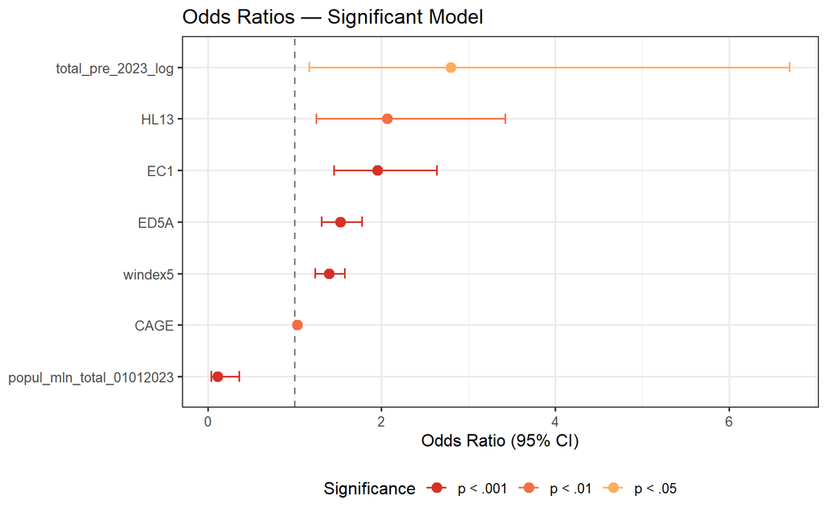

```r
# Plots
# Coefficient plot (OR forest plot) for model_sign

coef_df <- tidy(model_sign, effects = "fixed", conf.int = TRUE, exponentiate = TRUE) %>%
  filter(term != "(Intercept)") %>%
  mutate(
    sig = case_when(
      p.value < 0.001 ~ "p < .001",
      p.value < 0.01  ~ "p < .01",
      p.value < 0.05  ~ "p < .05",
      TRUE            ~ "n.s."
    ),
    sig = factor(sig, levels = c("p < .001", "p < .01", "p < .05", "n.s."))
  )

p_coef <- ggplot(coef_df, aes(x = estimate, y = reorder(term, estimate), color = sig)) +
  geom_vline(xintercept = 1, linetype = "dashed", color = "grey50") +
  geom_errorbar(aes(xmin = conf.low, xmax = conf.high), height = 0.2) +
  geom_point(size = 3) +
  scale_color_manual(
    values = c("p < .001" = "#d73027", "p < .01" = "#f46d43",
               "p < .05" = "#fdae61", "n.s." = "grey60")
  ) +
  labs(
    title    = "Odds Ratios — Significant Model",
    x        = "Odds Ratio (95% CI)",
    y        = NULL,
    color    = "Significance"
  ) +
  theme_bw(base_size = 12) +
  theme(legend.position = "bottom")

print(p_coef)
```

```
## `height` was translated to `width`.
```

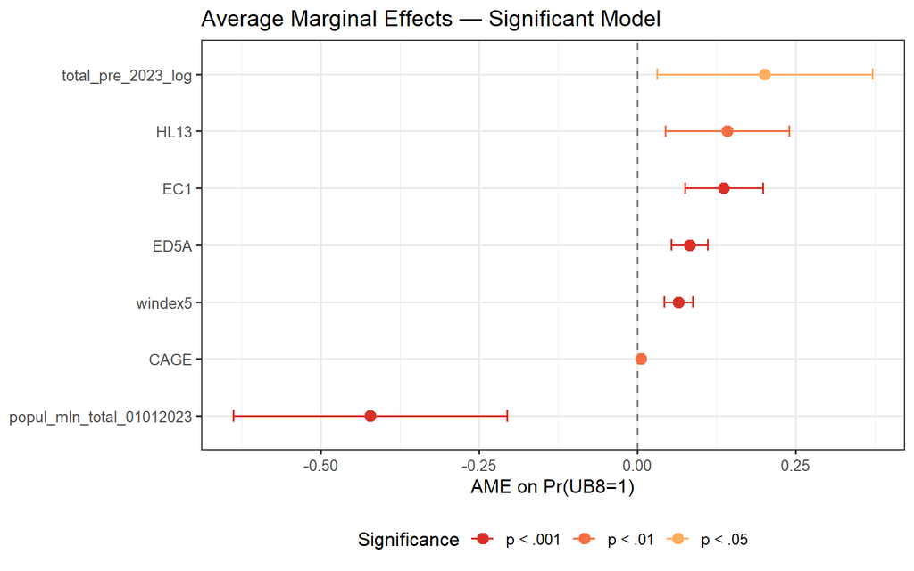

```r
# Marginal effects plot (AME)
ame_df <- as.data.frame(ame_model_sign) %>%
  filter(term != "(Intercept)") %>%
  mutate(
    sig = case_when(
      p.value < 0.001 ~ "p < .001",
      p.value < 0.01  ~ "p < .01",
      p.value < 0.05  ~ "p < .05",
      TRUE            ~ "n.s."
    ),
    sig = factor(sig, levels = c("p < .001", "p < .01", "p < .05", "n.s."))
  )

p_ame <- ggplot(ame_df, aes(x = estimate, y = reorder(term, estimate), color = sig)) +
  geom_vline(xintercept = 0, linetype = "dashed", color = "grey50") +
  geom_errorbarh(aes(xmin = conf.low, xmax = conf.high), height = 0.2) +
  geom_point(size = 3) +
  scale_color_manual(
    values = c("p < .001" = "#d73027", "p < .01" = "#f46d43",
               "p < .05" = "#fdae61", "n.s." = "grey60")
  ) +
  labs(
    title = "Average Marginal Effects — Significant Model",
    x     = "AME on Pr(UB8=1)",
    y     = NULL,
    color = "Significance"
  ) +
  theme_bw(base_size = 12) +
  theme(legend.position = "bottom")

print(p_ame)
```

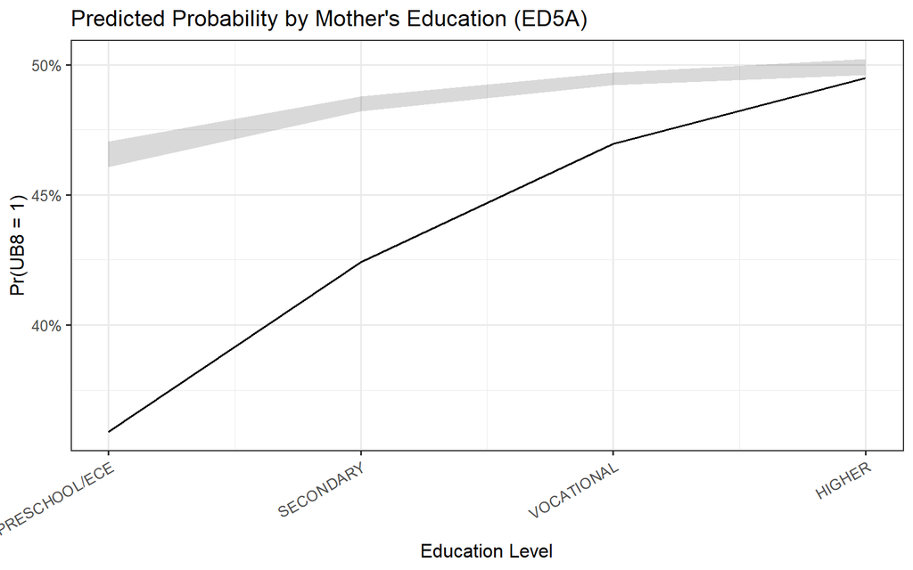

```r
#  Predicted probabilities for key predictors
pred_ed5a <- ggpredict(model_sign, terms = "ED5A [all]", bias_correction = TRUE)
p_ed5a <- plot(pred_ed5a) +
  labs(title = "Predicted Probability by Mother's Education (ED5A)",
       x = "Education Level", y = "Pr(UB8 = 1)") +
  theme_bw(base_size = 12)+
  theme(axis.text.x = element_text(angle = 30, hjust = 1))

pred_windex <- ggpredict(model_sign, terms = "windex5 [all]", bias_correction = TRUE)
p_windex <- plot(pred_windex) +
  labs(title = "Predicted Probability by Wealth Index",
       x = "Wealth Index (windex5)", y = "Pr(UB8 = 1)") +
  theme_bw(base_size = 12)

print(p_ed5a)
```

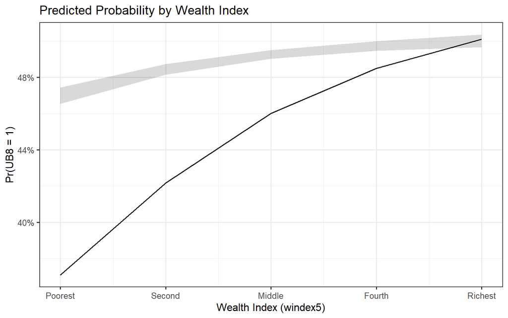

```r
print(p_windex)
```

```
## `height` was translated to `width`.
```

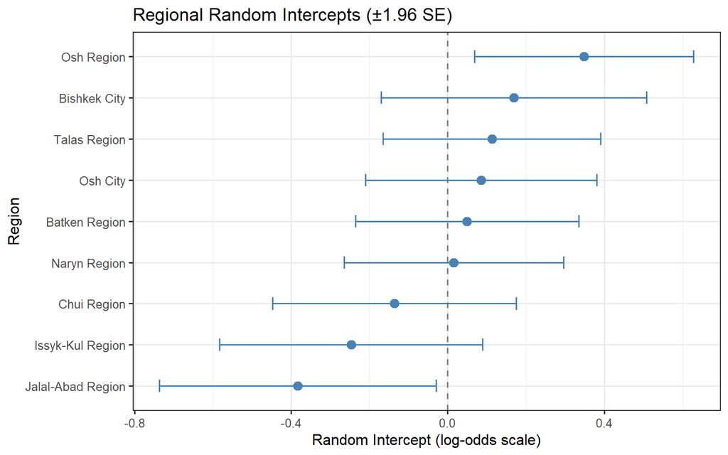

```r
#  4. Random effects (regional variation)
re_df <- ranef(model_sign, condVar = TRUE)$region %>%
  tibble::rownames_to_column("region") %>%
  rename(intercept = `(Intercept)`) %>%
  mutate(
    se = sqrt(attr(ranef(model_sign, condVar = TRUE)$region, "postVar")[1, 1, ]),
    lower = intercept - 1.96 * se,
    upper = intercept + 1.96 * se
  )

p_re <- ggplot(re_df, aes(x = intercept, y = reorder(region, intercept))) +
  geom_vline(xintercept = 0, linetype = "dashed", color = "grey50") +
  geom_errorbarh(aes(xmin = lower, xmax = upper), height = 0.3, color = "steelblue") +
  geom_point(size = 3, color = "steelblue") +
  labs(
    title = "Regional Random Intercepts (±1.96 SE)",
    x     = "Random Intercept (log-odds scale)",
    y     = "Region"
  ) +
  theme_bw(base_size = 12)

print(p_re)
```

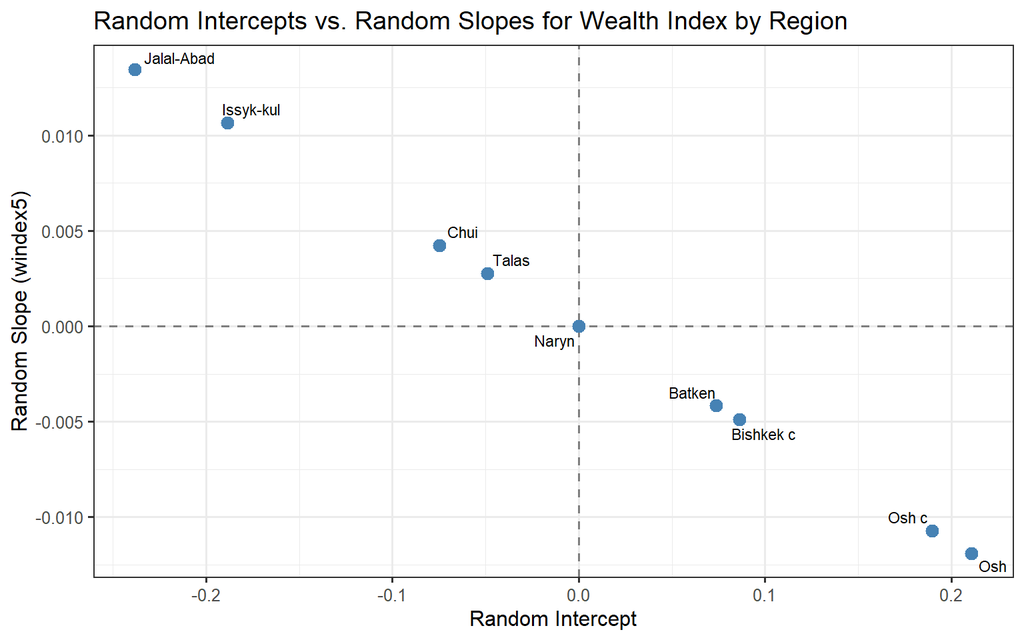

```r
#  5. Random slopes by region (model_extra: windex5 | region_mics)
re_slopes_df <- ranef(model_extra, condVar = TRUE)$region_mics %>%
  tibble::rownames_to_column("region") %>%
  rename(intercept = `(Intercept)`, slope_windex = windex5)

p_slopes <- ggplot(re_slopes_df, aes(x = intercept, y = slope_windex, label = region)) +
  geom_hline(yintercept = 0, linetype = "dashed", color = "grey50") +
  geom_vline(xintercept = 0, linetype = "dashed", color = "grey50") +
  geom_point(size = 3, color = "steelblue") +
  ggrepel::geom_text_repel(size = 3) +
  labs(
    title = "Random Intercepts vs. Random Slopes for Wealth Index by Region",
    x     = "Random Intercept",
    y     = "Random Slope (windex5)"
  ) +
  theme_bw(base_size = 12)

print(p_slopes)
```

```r
#  ICC and R² across models — summary bar chart
model_list <- list(
  "Null"        = model_null,
  "For Pooling" = model_for_pooling,
  "Full"        = model_full,
  "Significant" = model_sign,
  "Extra"       = model_extra
)

r2_df <- purrr::map_dfr(names(model_list), function(nm) {
  r2_vals <- r2(model_list[[nm]])
  icc_result <- tryCatch(
    performance::icc(model_list[[nm]])$ICC_adjusted,
    error = function(e) NA_real_
  )

  tibble::tibble(
    model        = nm,
    R2_marginal  = r2_vals$R2_marginal,
    R2_conditional = r2_vals$R2_conditional,
    ICC          = icc_result
  )
}) %>%
  tidyr::pivot_longer(-model, names_to = "metric", values_to = "value") %>%
  mutate(model = factor(model, levels = names(model_list)))
```

```
## Random effect variances not available. Returned R2 does not account for random effects.
```

```
## boundary (singular) fit: see help('isSingular')
```

```
## Random effect variances not available. Returned R2 does not account for random effects.
```

```
## boundary (singular) fit: see help('isSingular')
```

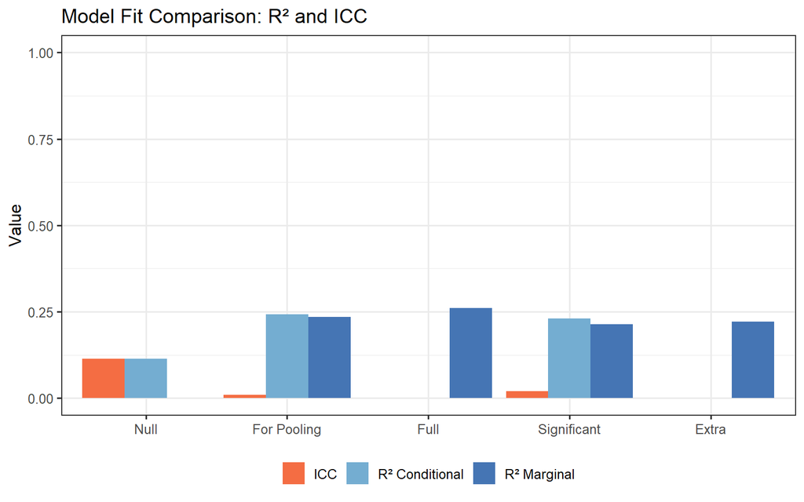

```r
p_r2 <- ggplot(r2_df, aes(x = model, y = value, fill = metric)) +
  geom_col(position = "dodge") +
  scale_fill_manual(
    values = c("R2_marginal" = "#4575b4", "R2_conditional" = "#74add1", "ICC" = "#f46d43"),
    labels = c("ICC", "R² Conditional", "R² Marginal")
  ) +
  labs(
    title = "Model Fit Comparison: R² and ICC",
    x     = NULL,
    y     = "Value",
    fill  = NULL
  ) +
  ylim(0, 1) +
  theme_bw(base_size = 12) +
  theme(legend.position = "bottom")

print(p_r2)
```

# Model predictive performance comparison

```r
# Splitting data

kgz_df <- kgz_df %>%
  mutate(strata_var = paste0(region_mics, "_", UB8))

train_idx <- createDataPartition(kgz_df$strata_var, p = 0.75, list = FALSE)
train_df  <- kgz_df[train_idx, ]
test_df   <- kgz_df[-train_idx, ]


# Refit all models on training data
# Swapping kgz_df to train_df in each model call
# Example:
model_null_train <- update(model_null, data = train_df)
model_pool_train <- update(model_for_pooling, data = train_df)
model_full_train <- update(model_full, data = train_df)
```

```
## boundary (singular) fit: see help('isSingular')
```

```r
model_sign_train <- update(model_sign, data = train_df)
model_extra_train <- update(model_extra, data = train_df)
```

```
## boundary (singular) fit: see help('isSingular')
```

```r
# Predict test set
# allow.new.levels = TRUE handles regions in test not seen in train
predict_prob <- function(model, newdata) {
  predict(model, newdata = newdata, type = "response", allow.new.levels = TRUE)
}

probs <- list(
  Null = predict_prob(model_null_train, test_df),
  For_Pooling = predict_prob(model_pool_train, test_df),
  Full = predict_prob(model_full_train, test_df),
  Significant = predict_prob(model_sign_train, test_df),
  Extra = predict_prob(model_extra_train, test_df)
)


# Metrics

metrics_df <- purrr::map2_dfr(
  probs, names(probs),
  ~ compute_metrics(.x, as.numeric(as.character(test_df$UB8)), .y)
)
```

# Performance comparison table

```r
metrics_df %>%
  mutate(across(where(is.numeric), ~ round(.x, 3))) %>%
  gt::gt() %>%
  gt::tab_header(title = "Out-of-Sample Prediction Accuracy Comparison") %>%
  gt::fmt_number(columns = where(is.numeric), decimals = 3) %>%
  gt::cols_label(
    Model       = "Model",
    AUC         = "AUC",
    Accuracy    = "Accuracy",
    Sensitivity = "Sensitivity",
    Specificity = "Specificity",
    PPV         = "Precision (PPV)",
    F1          = "F1 Score",
    Brier       = "Brier Score",
    LogLoss     = "Log Loss"
  ) %>%
  gt::tab_style(
    style = gt::cell_fill(color = "#d4edda"),
    locations = gt::cells_body(
      rows = Accuracy == max(Accuracy)
    )
  )
```

Out-of-Sample Prediction Accuracy Comparison

| Model | AUC | Accuracy | Sensitivity | Specificity | Precision (PPV) | F1 Score | Brier Score | Log Loss |
| --- | --- | --- | --- | --- | --- | --- | --- | --- |
| Null | 0.668 | 0.649 | 0.345 | 0.833 | 0.556 | 0.426 | 0.215 | 0.616 |
| For_Pooling | 0.727 | 0.701 | 0.466 | 0.844 | 0.643 | 0.540 | 0.199 | 0.582 |
| Full | 0.741 | 0.701 | 0.448 | 0.854 | 0.650 | 0.531 | 0.196 | 0.576 |
| Significant | 0.736 | 0.692 | 0.448 | 0.839 | 0.627 | 0.523 | 0.197 | 0.576 |
| Extra | 0.737 | 0.688 | 0.457 | 0.828 | 0.616 | 0.525 | 0.197 | 0.577 |

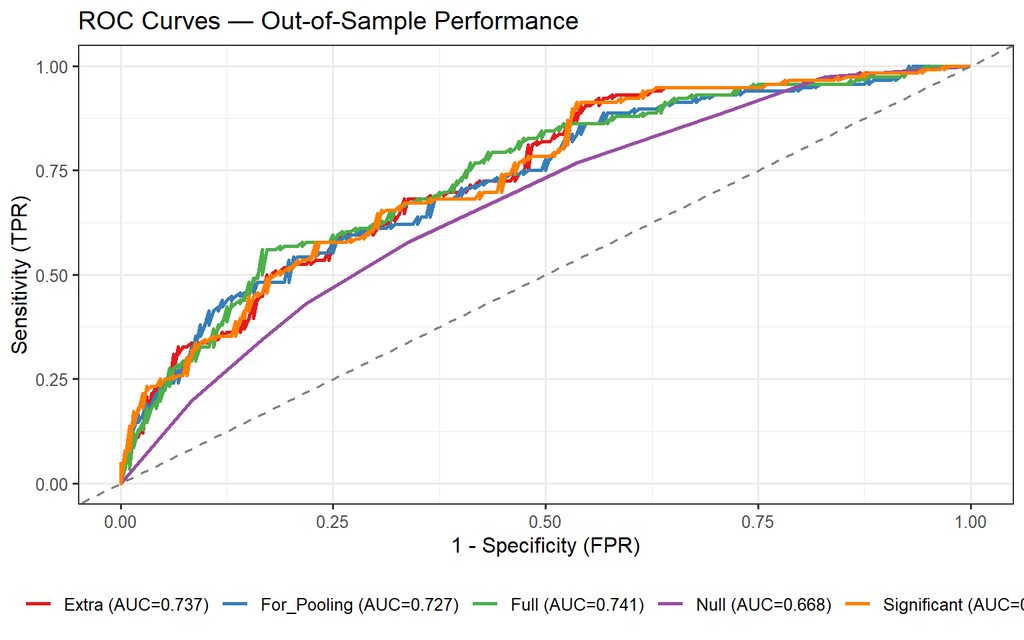

```r
# ROC curves plot (all models)
roc_list <- purrr::map2(probs, names(probs), function(p, nm) {
  roc_obj <- roc(as.numeric(as.character(test_df$UB8)), p, quiet = TRUE)
  data.frame(
    model       = paste0(nm, " (AUC=", round(auc(roc_obj), 3), ")"),
    sensitivity = roc_obj$sensitivities,
    specificity = roc_obj$specificities
  )
})

roc_df <- dplyr::bind_rows(roc_list)

p_roc <- ggplot(roc_df, aes(x = 1 - specificity, y = sensitivity, color = model)) +
  geom_line(linewidth = 0.9) +
  geom_abline(slope = 1, intercept = 0, linetype = "dashed", color = "grey50") +
  scale_color_brewer(palette = "Set1") +
  labs(
    title = "ROC Curves — Out-of-Sample Performance",
    x     = "1 - Specificity (FPR)",
    y     = "Sensitivity (TPR)",
    color = NULL
  ) +
  theme_bw(base_size = 12) +
  theme(legend.position = "bottom")

print(p_roc)
```

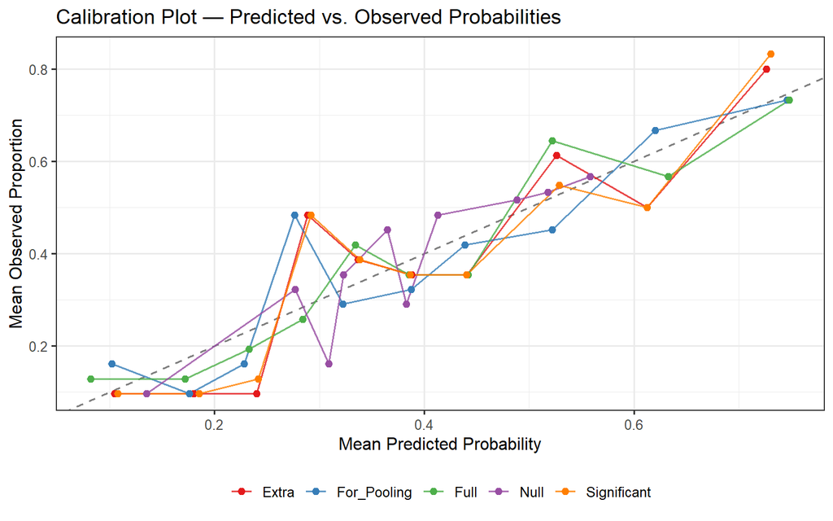

```r
# Calibration plot — predicted vs. observed probabilities
cal_df <- purrr::map2_dfr(probs, names(probs), function(p, nm) {
  data.frame(
    model    = nm,
    pred     = p,
    observed = as.numeric(as.character(test_df$UB8))
  )
})

# Bin predictions into deciles per model
cal_binned <- cal_df %>%
  dplyr::group_by(model) %>%
  dplyr::mutate(bin = ntile(pred, 10)) %>%
  dplyr::group_by(model, bin) %>%
  dplyr::summarise(
    mean_pred = mean(pred),
    mean_obs  = mean(observed),
    .groups   = "drop"
  )

p_cal <- ggplot(cal_binned, aes(x = mean_pred, y = mean_obs, color = model)) +
  geom_abline(slope = 1, intercept = 0, linetype = "dashed", color = "grey50") +
  geom_line(linewidth = 0.7, alpha = 0.8) +
  geom_point(size = 2) +
  scale_color_brewer(palette = "Set1") +
  labs(
    title = "Calibration Plot — Predicted vs. Observed Probabilities",
    x     = "Mean Predicted Probability",
    y     = "Mean Observed Proportion",
    color = NULL
  ) +
  theme_bw(base_size = 12) +
  theme(legend.position = "bottom")

print(p_cal)
```